# Chapter 06 Exercises

## Jae Wook Jung

### Feb. 12. 2020

```python
# Insert the Python Libraries You Will Need Here:
import numpy as np
import matplotlib.pyplot as plt
import pandas as pd
```

## Q1) Implementing the Romer Model using Python

Unlike the Solow Model, the Romer model incorporates the difference between ideas and ojects into the model. Ideas play a big role in sustained growth as illustrated by this homework.

### Part I

| Description | Formula |
| --- | --- |
| Unknowns/endogenous variables: | $Y_t$, $A_t$, $L_{yt}$, $L_{at}$ |
| Output Production Function: | $Y_t = A_tL_{yt}$ |
| Idea Production Function: | $\Delta A_{t+1}=\bar{z}A_tL_{at}$ |
| Resource Constraint: | $L_{yt}+L_{at}=\bar{L}$ |
| Allocation of Labor: | $L_{at} = \bar{\ell}\bar{L}$ |
| Parameters: | $\bar{z}, \bar{L}, \bar{\ell}, \bar{A_0}$ |

Suppose the parameters of the Romer model take the following values: $\bar{A_0} = 100$, $\bar{\ell} = 0.10$, $\bar{z} = \frac{1}{500}$, and $\bar{L} = 100$.

**(a):** What is the growth rate of output per person in this economy? Calculate this by hand and input your answer here.

```python
z = 1/500
l = 0.1
L = 100
g = z*l*L
print(g)
```

```
0.02
```

**(b):** What is the initial level of output per person? See equation 6.9 (pg. 149 of the textbook). Calculate this by hand and input your answer here.

```python
A0 = 100
y0 = A0 * (1 + z*l*L)**(0) * (1 - l)
print(y0)
```

```
90.0
```

**(c):** Use the Romer framework to model output per person over 80 years and make two time series plots, one in the level scale and another using the ratio scale.

```
0.02
```

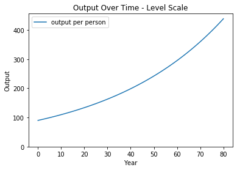

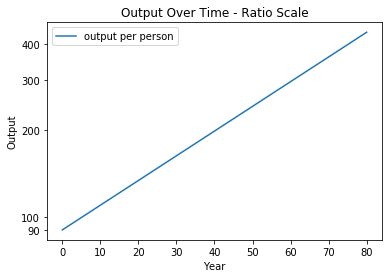

```python
# Initial parameter values
A0 = 100
l = 0.1
z = 1/500
L = 100
g = z*l*L
t_0 = 0
def output_per_person(A0, g, t, l):
    return A0 * (1 - l) * ((1 + g)**(t) )

# Create arrays for time and output. Hint: You can use a loop or a linspace array for this
i = 0
time = [0]
Output_p = np.array([output_per_person(A0, g, t_0, l)])
while i < 80:
    i += 1
    time = np.append(time, i)
    Output_p = np.append(Output_p, output_per_person(A0, g, time[i], l))


# Make the plots
print(g)
plt.plot(time, Output_p, label = 'output per person')
plt.title('Output Over Time - Level Scale')
plt.xlabel('Year')
plt.ylabel('Output')
plt.yticks([0, 100, 200, 300, 400])
plt.legend()
plt.show()


plt.plot(time, Output_p, label = 'output per person')
plt.yscale('log')
plt.title('Output Over Time - Ratio Scale')
plt.xlabel('Year')
plt.ylabel('Output')
plt.yticks([90, 100, 200, 300, 400], ['90', '100', '200', '300', '400'])
plt.legend()
plt.show()
```

**(d):** Suppose the share or workers dedicated to research were to double at $t=40$. Please answer **(a)** and **(b)** using this new information? Add this change to the graphs of part **(c)**. You will now have two 80-year paths for each variable on one plot. Make sure your time series for this question has a different color and that your plot includes a legend indicating which parameter values belong to which variable path. Please discuss the effect on output generated by the change in the allocation of labor in this economy.

```
0.04
176.64317308918828
```

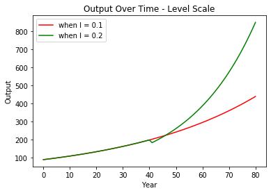

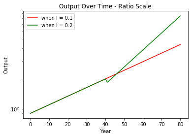

```python
# Defining new research labor share



##########################################################################
# Part (a): find the growth rate
##########################################################################
l2 = 2* l
gr = z * l2 * L
print(gr)
A40 = A0 * (1 + g)**(40)
##########################################################################
# Part (b): The initial level of output per person
##########################################################################
y00 = A40 * (1 + gr)**(0) * (1 - l2)

print(y00)

##########################################################################
# Part (c): Make a plot of 80 years of output
##########################################################################
i=0
time = [0]
l2 = 2* l
gr = z * l2 * L
A40 = A0 * (1 + g)**(40)
Output_p = np.array([output_per_person(A0, g, time[0], l)])
Output_p1 = np.array([output_per_person(A40, gr, 0, l2)])

for i in range(0,80):
    i += 1
    time = np.append(time, i)
    Output_p = np.append(Output_p, output_per_person(A0, g, time[i], l))


# Allocate new array
i = 0
time = [0]
Output_p1 = np.array([output_per_person(A0, g, t_0, l)])
for i in range(0,80):
    if(i<40):
        i += 1
        time = np.append(time, i)
        Output_p1 = np.append(Output_p1, output_per_person(A0, g, time[i], l))

    else:
        i += 1
        time = np.append(time, i)
        Output_p1 = np.append(Output_p1, output_per_person(A40, gr, time[i - 40], l2))


# To simulate the change in the research share we have to be very careful about timing.
# At period 40 the research share will change the level of output immediately. It will
# also change the growth rate of output from period 40 onward.  In essence it creates
# another time series, independent from the previous one. Instead of creating
# two time series and joining them like I did in HW Ch5 I've used
# an 'if' statment inside of the loop. It's business as usual from periods 1-39. However
# in period 40 the research share changes both the level of output, and the growth rate of output.
# Note I kept the value of TFP fom period 40 to start the new series.




# Make the plots
plt.plot(time, Output_p, color = 'red', label = 'when l = 0.1')
plt.plot(time, Output_p1, color = 'green', label = 'when l = 0.2')
plt.title('Output Over Time - Level Scale')
plt.xlabel('Year')
plt.ylabel('Output')
plt.legend()
plt.show()


plt.plot(time, Output_p, color = 'red', label = 'when l = 0.1')
plt.plot(time, Output_p1, color = 'green', label = 'when l = 0.2')
plt.yscale('log')
plt.title('Output Over Time - Ratio Scale')
plt.xlabel('Year')
plt.ylabel('Output')
plt.legend()
plt.show()
```

because labors for output becomes less, the output immediately falls a bit. But more labors for research makes growth rate higher, after some period later there will be more output.

### Part II

Now suppose the parameters of the model take the following values $\bar{A_0} = 100$, $\bar{\ell} = 0.06$, $\bar{z} = \frac{1}{3000}$, and $\bar{L} = 1000$. Use Python to answer **(a)** through **(c)**.

**(a):** What is the growth rate of output per person in this economy? What is the initial level of output per person?

```python
A0 = 100
l = 0.06
z = 1/3000
L = 1000
g = z*l*L
yt0 = A0 * (1 + g)**(0) * (1 - l)
print(g)
print(yt0)
```

```
0.019999999999999997
94.0
```

**(b):** Use the Romer framework to model output per person over 80 years and make a time series plot using the *levels* scale.

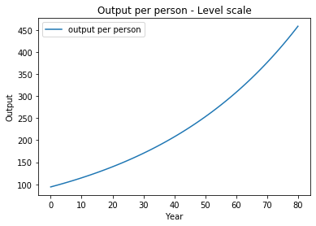

```python
def output_per_person(A0, g, t, l):
    return A0 * (1 + g)**(t) * (1 - l)
i = 0
time = [0]
yt = np.array(output_per_person(A0, g, time[0], l))
while i < 80:
    i += 1
    time = np.append(time, i)
    yt = np.append(yt, output_per_person(A0, g, time[i], l))

plt.plot(time, yt, label = 'output per person')
plt.title('Output per person - Level scale')
plt.xlabel('Year')
plt.ylabel('Output')
plt.legend()
plt.show()
```

**(c):** Now add to your plot from part **(b)** the following changes one at a time: a doubling of the stock of knowledge $\bar{A}_{20}$ at $t=20$, an increase of the research share $\bar{\ell}$ by 150% at $t=30$, double the research productivity $\bar{z}$ at $t=40$, and a doubling of the population $\bar{L}$ at $t=60$. You should now have a total of 5 separate time series on the same plot. Make sure each line has a different color and your plot has a legend indicating which path represents which change. Please, make sure to include the growth rate of output per person after the change in the legend for each scenario.

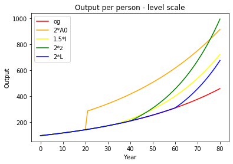

```python
time = [0]
i = 0
yt0 = np.array(output_per_person(A0, g, time[0], l))

for i in range(0, 80):
     i += 1
     time = np.append(time, i)
     yt0 = np.append(yt0, output_per_person(A0, g, time[i], l))

##########
time = [0]
i = 0
yt1 = output_per_person(A0, g, time[0], l)
A20 = A0 * (1 + g)**(20) * 2  ######  ?
for i in range(0, 80):

    if (i < 20):
     i += 1
     time = np.append(time, i)
     yt1 = np.append(yt1, output_per_person(A0, g, time[i], l))


    else:
     i += 1
     time = np.append(time, i)
     yt1 = np.append(yt1, output_per_person(A20, g, time[i - 20], l))

###################
time = [0]
i = 0
yt2 = output_per_person(A0, g, time[0], l)
l30 = 1.5 * l
A30 = A0 * (1 + g)**(30)
g1 = l30 * z * L
for i in range(0, 80):
    if (i < 30):
     i += 1
     time = np.append(time, i)
     yt2 = np.append(yt2, output_per_person(A0, g, time[i], l))

    else:
     i += 1
     time = np.append(time, i)
     yt2 = np.append(yt2, output_per_person(A30, g1, time[i - 30], l30))

###################
time = [0]
i = 0
yt3 = output_per_person(A0, g, time[0], l)
g2 = l * L * 2* z
A40 = A0 * (1 + g)**(40)
for i in range(0, 80):
    if (i < 40):
     i += 1
     time = np.append(time, i)
     yt3 = np.append(yt3, output_per_person(A0, g, time[i], l))

    else:
     i += 1
     time = np.append(time, i)
     yt3 = np.append(yt3, output_per_person(A40, g2, time[i - 40], l))

###################
time = [0]
i = 0
yt4 = output_per_person(A0, g, time[0], l)
g3 = l * z * 2*L
A60 = A0 * (1 + g)**(60)
for i in range(0, 80):
    if(i < 60):
     i += 1
     time = np.append(time, i)
     yt4 = np.append(yt4, output_per_person(A0, g, time[i], l))

    else:
     i += 1
     time = np.append(time, i)
     yt4 = np.append(yt4, output_per_person(A60, g3, time[i - 60], l))



plt.plot(time, yt0, 'red', label ='og')
plt.plot(time, yt1, 'orange', label = '2*A0')
plt.plot(time, yt2, 'yellow', label = '1.5*l')
plt.plot(time, yt3, 'green', label = '2*z')
plt.plot(time, yt4, 'blue', label = '2*L')
plt.title('Output per person - level scale')
plt.xlabel('Year')
plt.ylabel('Output')
plt.legend()
plt.show()
```

**(d):** Now you have a framework to conduct quantitative experiments at different time frames with different variables. Play around with each event and suggest which change to the model would result in the greatest gain for an economy in the long run. Make sure to back up your claims with numbers!

**Answer:** doubling research productivity, z, at period 40 change is gaining the most. Doubling z and L have the same effects, but since z started earlier the output per person is higher.

```python
print(output_per_person(A40, g2, time[i - 40], l))
```

```
996.4793333978193
```

## Q2) Intellectual property products (a FRED question)

In 2015, the U.S. National Income Accounts began to "count" intellectual property products—such as R&D, computer software, books, music, and movies—explicitly as investment. More correctly, they had previously assumed these products were an intermediate good that depreciated fully when used to produce some other final good, but now they are included as a part of investment and GDP. Examine the data on investment in intellectual property products (IPP).

**(a)** Create a time series plot that shows the research share over time. Please use the code from the Chapter 07 Homework **Q1)** as a guide.

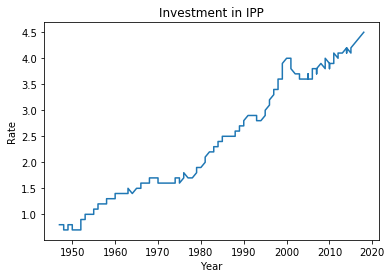

```python
#press shift + enter to run this code
# url: 'https://raw.githubusercontent.com/dylanjm/econ_381_development/master/data/Y001RE1Q156NBEA.csv',

data = pd.read_csv("https://raw.githubusercontent.com/dylanjm/econ_381_development/master/data/Y001RE1Q156NBEA.csv", header = 0, names = ["Date", "Rate"])
data['Date'] = pd.to_datetime(data['Date'])
data['Year'] = data['Date'].dt.year

plt.plot(data['Year'], data['Rate'])
plt.xlabel('Year')
plt.ylabel('Rate')
plt.title('Investment in IPP')
plt.show()
```

**(b):** What has happened to the share of GDP devoted to investment in IPP over the last 60 years. What might explain this change?

The nation is protecting IPP for the companies. The investment in IPP has grown up. People found out that investing in IPP makes more money than solely manufacturing. And IPP is nonrival so since a company find one good invention, it can enjoy its development.

**(c):** Lets use the share of GDP devoted to investment in IPP as a proxy for the amount of effort that goes into research and development in a country, or $\bar{\ell}$. The assumption in the Romer model is that the research share is constant. Please relax this assumption and incorporate a dynamic research share parameter $\bar{\ell}_{t}$ into the Romer model. Use the data you obtained in part **(b)** to create a series for your new dynamic variable $\bar{\ell}_{t}$ and simluate all 287 quarters of data found in the of data using $\bar{A_0} = 100$, $\bar{z} = \frac{1}{3000}$, $\alpha=1/3$ and $\bar{L} = 1000$. Please create a plot of GDP per capital and the growth of GPD per capital over the post WWII era.

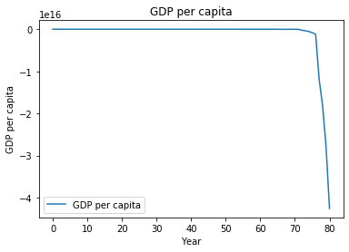

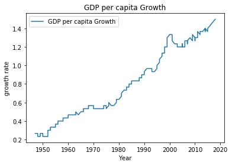

```python
# Assign the data from FRED as l(t)

data['Date'] = pd.to_datetime(data['Date'])
data['Year'] = data['Date'].dt.year


data1 = data['Rate']

# output = lambda A0, z, data1, L, t:A0 * (1 + z*data1*L)**(t) * (1 - data1)

# Preallocate arrays to be filled in later
# output1 = np.zeros(287)
# growth = np.zeros(287)
year = np.arange(0, 81, 1)



# Assign parameter values
A0 = 100
z = 1/3000
L = 1000
g = data1 * z * L
t = [0]
l = data1

def GDP_per_capital(A0, g, t, l):
        return A0 * (1 + g)**(t) * (1 - l)

   # Using a for loop, calculate output and growth rates

# for i in range(0, 287):
 #   t = i
 #   growth[i] = z * data[i] * L
 #   output1[i] = output(A0, z, data1[i], L, t)


growth = g

i = 0
GDP = GDP_per_capital(A0, g[0], time[0], l[0])

for i in range(0, 80):
   i += 1
   t = np.append(t, i)
   GDP = np.append(GDP, GDP_per_capital(A0, growth[i], time[i], data1[i]))



# Create a plot of output
plt.plot(year, GDP, label = 'GDP per capita')
plt.title('GDP per capita')
plt.xlabel('Year')
plt.ylabel('GDP per capita')
plt.legend()
plt.show()

# Create a plot of growth
plt.plot(data["Year"], growth, label = 'GDP per capita Growth')
plt.title('GDP per capita Growth')
plt.xlabel('Year')
plt.ylabel('growth rate')
plt.legend()
plt.show()
```

```python
print(data1[82])
```

```
1.6
```

**(d)** Compare the growth rate of GDP per capita under this new assumption versus the fixed parameter version of the model. What are the strenghts and weaknesses of each model? Please justify your answers.

the new assumption is that the growth rate is increasing trend. GDP pe capita is flat and falls deeply. I know that the graph is wrong. Just comparing increasing growth rate and fixed growth rate in GDP per capita, increasing growth rate GDP per capita will have steeper than fixed growth rate per capita graph. Becuase the growth rate is keep increasing, the slope will get steeper and steeper.